# Рекомендация тарифов

## Описание проекта

Оператор мобильной связи «Мегалайн» выяснил: многие клиенты пользуются архивными тарифами. Они хотят построить систему, способную проанализировать поведение клиентов и предложить пользователям новый тариф: «Смарт» или «Ультра».  
В нашем распоряжении данные о поведении клиентов, которые уже перешли на эти тарифы. Нужно построить модель для задачи классификации, которая выберет подходящий тариф. Предобработка данных не понадобится. Необходимо построить модель с максимально большим значением accuracy. Нужно довести долю правильных ответов по крайней мере до 0.75 и проверить accuracy на тестовой выборке.

## Ход выполнения проекта

Проект будем выполнять в 5 этапов:

1. Откроем файл с данными и изучим его общую информацию.
2. Разделим исходные данные на обучающую, валидационную и тестовую выборки.
3. Исследуем качество разных моделей, меняя гиперпараметры.
4. Проверим качество модели на тестовой выборке.
5. Проверим модели на вменяемость.

## Описание данных

Каждый объект в наборе данных — это информация о поведении одного пользователя за месяц. Известно:

- `сalls` — количество звонков,
- `minutes` — суммарная длительность звонков в минутах,
- `messages` — количество sms-сообщений,
- `mb_used` — израсходованный интернет-трафик в Мб,
- `is_ultra` — каким тарифом пользовался в течение месяца («Ультра» — 1, «Смарт» — 0).

## Изучение общей информации

```python
# импорт библиотек
import pandas as pd
import seaborn as sns
import numpy as np
import random

from sklearn.tree import DecisionTreeClassifier # дерево принятия решений
from sklearn.ensemble import RandomForestClassifier # случайный лес
from sklearn.linear_model import LogisticRegression # логистическая регрессия
from sklearn.model_selection import train_test_split # разделение выборок
from sklearn.metrics import mean_squared_error # среднеквадратичная ошибка
from sklearn.metrics import accuracy_score # оценка доли правильных ответов
from sklearn.dummy import DummyClassifier # простейшая baseline модель
```

```python
# считывание csv-файла
try:
    df = pd.read_csv('/datasets/users_behavior.csv')
except:
    df = pd.read_csv('users_behavior.csv')

# увеличим максимальное количество отображающихся столбцов
pd.set_option('display.max_columns', None)
```

```python
# выведем первые 5 строк датафрейма
df.head()
```

|  | calls | minutes | messages | mb_used | is_ultra |
| --- | --- | --- | --- | --- | --- |
| 0 | 40.0 | 311.90 | 83.0 | 19915.42 | 0 |
| 1 | 85.0 | 516.75 | 56.0 | 22696.96 | 0 |
| 2 | 77.0 | 467.66 | 86.0 | 21060.45 | 0 |
| 3 | 106.0 | 745.53 | 81.0 | 8437.39 | 1 |
| 4 | 66.0 | 418.74 | 1.0 | 14502.75 | 0 |

```python
# выведем общую информацию о таблице
df.info()
```

```
<class 'pandas.core.frame.DataFrame'>
RangeIndex: 3214 entries, 0 to 3213
Data columns (total 5 columns):
 #   Column    Non-Null Count  Dtype
---  ------    --------------  -----
 0   calls     3214 non-null   float64
 1   minutes   3214 non-null   float64
 2   messages  3214 non-null   float64
 3   mb_used   3214 non-null   float64
 4   is_ultra  3214 non-null   int64
dtypes: float64(4), int64(1)
memory usage: 125.7 KB
```

Изменим тип данных столбца `calls` и `messages` на целочисленный.

```python
df['calls'] = df['calls'].astype('int')
df['messages'] = df['messages'].astype('int')
```

Проверим дубликаты

```python
df.duplicated().sum()
```

```
0
```

```python
# выведем общую информацию о количественных данных в таблице
df.describe()
```

|  | calls | minutes | messages | mb_used | is_ultra |
| --- | --- | --- | --- | --- | --- |
| count | 3214.000000 | 3214.000000 | 3214.000000 | 3214.000000 | 3214.000000 |
| mean | 63.038892 | 438.208787 | 38.281269 | 17207.673836 | 0.306472 |
| std | 33.236368 | 234.569872 | 36.148326 | 7570.968246 | 0.461100 |
| min | 0.000000 | 0.000000 | 0.000000 | 0.000000 | 0.000000 |
| 25% | 40.000000 | 274.575000 | 9.000000 | 12491.902500 | 0.000000 |
| 50% | 62.000000 | 430.600000 | 30.000000 | 16943.235000 | 0.000000 |
| 75% | 82.000000 | 571.927500 | 57.000000 | 21424.700000 | 1.000000 |
| max | 244.000000 | 1632.060000 | 224.000000 | 49745.730000 | 1.000000 |

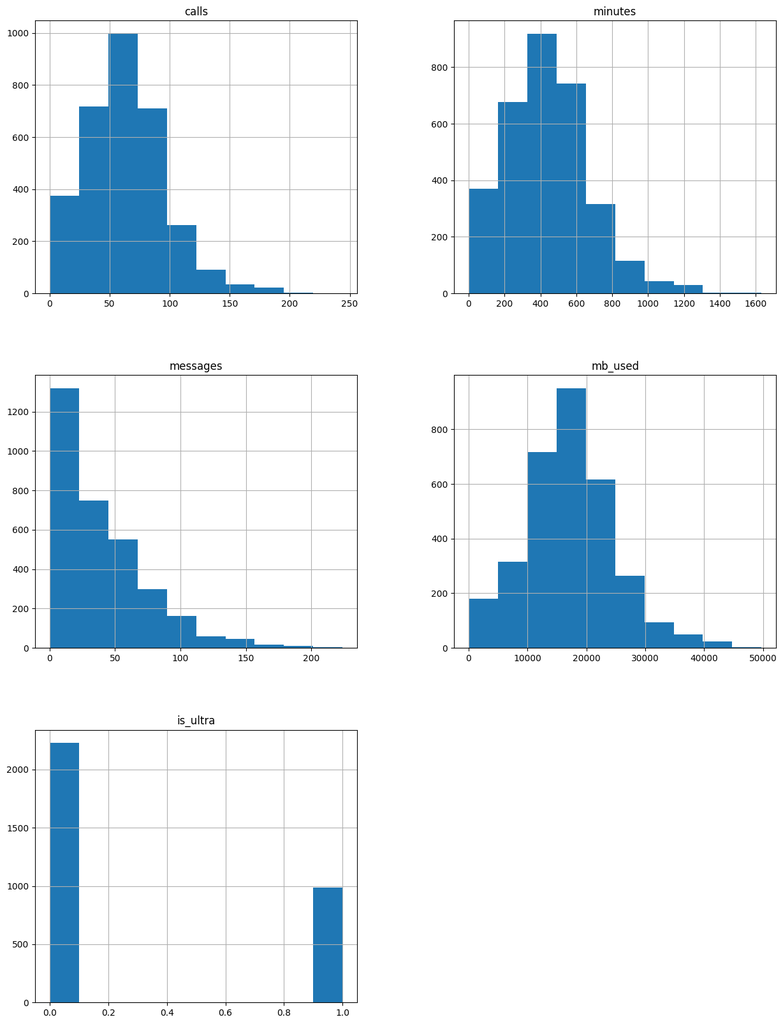

```python
# построим гистограмму для всех значений датафрейма
df.hist(figsize=(15,20));
```

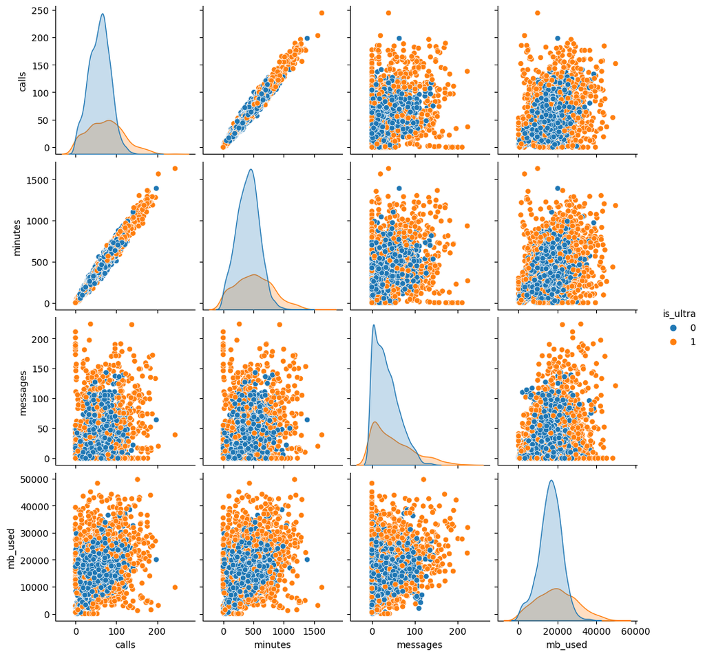

```python
# Посмотрим попарные отношения с целевым признаком
sns.pairplot(df, hue='is_ultra');
```

### Вывод

Таблица содержит более 3 тыс. значений и состоит и 5 столбцов. Пропуски в данных отсутствуют, данные соответствуют типам, согласно описанию, дубликаты также отсутствуют, следовательно, можем сделать вывод что данные прошли прдобработку.  
Количество звонков, длительность звонков в минутах, а также израсходованный интернет трафик имеют нормальные распределения. Количество пользователей с тарифом "Смарт" более, чем в 2 раза превышает количество пользователей с тарифом "Ультра".

## Разделение выборок

Разделим выборки на обучающую, валидационную и тестовую в соотношении 3:1:1. Также зафиксируем псевдослучайность для алгоритма обучения.

```python
# отделим 40% данных для валидационной и тестовой выборки
df_train, df_test1 = train_test_split(df, test_size=0.4, random_state=12345)

# поделим валидационную и тестовую выборки пополам (т.е. по 20% от исходного датасета)
df_valid, df_test = train_test_split(df_test1, test_size=0.5, random_state=12345)
```

Проверим, что использовали правильную логику для разделения данных и выведем количество значений в каждой из выборок.

```python
print('Размер обучающей выборки', df_train.shape)
print('Размер валидационной выборки', df_valid.shape)
print('Размер тестовой выборки', df_test.shape)
```

```
Размер обучающей выборки (1928, 5)
Размер валидационной выборки (643, 5)
Размер тестовой выборки (643, 5)
```

### Вывод

Выборки разделены: 60% от изначального датасета - обучающая выборка, 20% - валидационная и 20% - тестовая.

## Исследование моделей

Перед исследованием извлечем признаки и целевой признак в обучающей и валидационной выборках.

```python
# извлечем признаки и целевой признак в обучающей выборке
features_train = df_train.drop(['is_ultra'], axis=1)
target_train = df_train['is_ultra']

# извлечем признаки и целевой признак в валидационной выборке
features_valid = df_valid.drop(['is_ultra'], axis=1)
target_valid = df_valid['is_ultra']
```

### Дерево принятия решений (Decision Tree)

Обучать модель дерева принятия решений будем меняя глубину дерева от 1 до 100.

```python
best_model_dt = None
best_result_dt = 0
best_max_depth = 0
for depth in range(1, 101):
    # обучим модель с заданной глубиной дерева
    model = DecisionTreeClassifier(random_state=12345, max_depth=depth)
    model.fit(features_train, target_train)
    # получим предсказания модели
    predictions_valid = model.predict(features_valid)
    # посчитаем качество модели
    result = accuracy_score(target_valid, predictions_valid)
    if result > best_result_dt:
        best_model_dt = model
        best_result_dt = result
        best_max_depth = depth

print("Accuracy лучшей модели:", best_result_dt)
print("Лучшая точность при глубине дерева:", best_max_depth)
```

```
Accuracy лучшей модели: 0.7853810264385692
Лучшая точность при глубине дерева: 3
```

### Случайный лес (Random Forest)

Обучать модель случайного леса будем меняя число деревьев от 10 до 300 с шагом изменения 10.

```python
best_model_rf = None
best_result_rf = 0
est_best = 0
for est in range(10, 300, 10):
    # обучим модель с заданным количеством деревьев
    model = RandomForestClassifier(random_state=12345, n_estimators=est)
    model.fit(features_train, target_train)
    # получим предсказания модели
    predictions_valid = model.predict(features_valid)
    # посчитаем качество модели на валидационной выборке
    result = accuracy_score(target_valid, predictions_valid)
    if result > best_result_rf:
        best_model_rf = model
        best_result_rf = result
        est_best = est

print("Accuracy лучшей модели:", best_result_rf)
print("Лучшая точность при числе деревьев:", est_best)
```

```
Accuracy лучшей модели: 0.7916018662519441
Лучшая точность при числе деревьев: 50
```

### Логистическая регрессия (Logistic Regression)

```python
# обучим модель с использованием алгоритма 'lbfgs'
model_lr1 = LogisticRegression(random_state=12345, solver='lbfgs', max_iter=1000, tol=1e-5)
model_lr1.fit(features_train, target_train)
# получим предсказания модели
predictions_valid_lr = model_lr1.predict(features_valid)
# посчитаем качество модели на валидационной выборке
accuracy_lr = accuracy_score(predictions_valid_lr, target_valid)

print("Accuracy лучшей модели:", accuracy_lr)
```

```
Accuracy лучшей модели: 0.7107309486780715
```

```python
# обучим модель с использованием алгоритма 'lbfgs'
# “Сбалансированный” режим использует значения y для автоматической корректировки весов
model_lr2 = LogisticRegression(random_state=12345, solver='lbfgs', max_iter=1000, tol=1e-5, class_weight='balanced')
model_lr2.fit(features_train, target_train)
# получим предсказания модели
predictions_valid_lr = model_lr2.predict(features_valid)
# посчитаем качество модели на валидационной выборке
accuracy_lr = accuracy_score(predictions_valid_lr, target_valid)

print("Accuracy лучшей модели:", accuracy_lr)
```

```
Accuracy лучшей модели: 0.39502332814930013
```

```python
# обучим модель с использованием алгоритма 'liblinear'
model_lr3 = LogisticRegression(random_state=12345, solver='liblinear', max_iter=1000, tol=1e-5)
model_lr3.fit(features_train, target_train)
# получим предсказания модели
predictions_valid_lr = model_lr3.predict(features_valid)
# посчитаем качество модели на валидационной выборке
accuracy_lr = accuracy_score(predictions_valid_lr, target_valid)

print("Accuracy лучшей модели:", accuracy_lr)
```

```
Accuracy лучшей модели: 0.7573872472783826
```

```python
# обучим модель с использованием алгоритма 'liblinear'
# “Сбалансированный” режим использует значения y для автоматической корректировки весов
model_lr4 = LogisticRegression(random_state=12345, solver='liblinear', max_iter=1000, tol=1e-5, class_weight='balanced')
model_lr4.fit(features_train, target_train)
# получим предсказания модели
predictions_valid_lr = model_lr4.predict(features_valid)
# посчитаем качество модели на валидационной выборке
accuracy_lr = accuracy_score(predictions_valid_lr, target_valid)

print("Accuracy лучшей модели:", accuracy_lr)
```

```
Accuracy лучшей модели: 0.614307931570762
```

Accuracy лучшей модели логистической регрессии №3 составила 0.757 с использованием алгоритма `'liblinear'`.

### Вывод

Наилучшую точность 79,2% показала модель случайного леса с количество деревьев равным 50.  
Модель дерева принятия решения показала себя чуть хуже, ее точность составила 78,5% при максимальной глубине дерева равной 3.  
Модель логистической регрессии показала себя хуже всего, наилучший результат у нее - точность 75,7%. При чем изменение количества итераций обучения не повлияло на результат.

## Проверка качества модели на тестовой выборке

Проверку качества модели на тестовой выборке будем проводить для одной лучшей модели - Случайный лес.

Перед исследованием извлечем признаки и целевой признак в тестовой выборке.

```python
features_test = df_test.drop(['is_ultra'], axis=1)
target_test = df_test['is_ultra']
```

```python
# получим предсказания лучшей модели
predictions_test_rf = best_model_rf.predict(features_test)

# посчитаем качество моделей на тестовой выборке
accuracy_test_rf = accuracy_score(predictions_test_rf, target_test)

print('Accuracy тестовой выборки случайного леса:', accuracy_test_rf)
```

```
Accuracy тестовой выборки случайного леса: 0.7931570762052877
```

### Вывод

При проверки модели случайного леса на тестовой выборке точность модели повысилась на 0,1% по сравнению с работой модели на валидационной выборке, что свидетельствует об отсутствии переобучения модели.

## Проверка моделей на вменяемость

Для оценки вменяемости (адекватности) моделей в задачах классификации необходимо сравнивать модели со случайной. Для проведения данного сравнения напишем функцию, предсказывающую значение признака (тарифа) случайным образом, т.е. 50/50.

```python
predictions_random = np.random.randint(low=0, high=2, size=643)

# посчитаем качество модели на тестовой выборке
accuracy_random = accuracy_score(target_test, predictions_random)

print('Accuracy тестовой выборки:', accuracy_random)
```

```
Accuracy тестовой выборки: 0.47900466562986005
```

Случайные ответы ошибаются примерно в 50% случаев, что логично, т.к. у нас всего два тарифа. Все обученные модели ошибаются намного реже - примерно в 22-25% случаев, что свидетельствует об вменяемости (адекватности) работы моделей.

Дополнительно проверим модели на вменяемость введением в работу *baseline* модели - это самая наивная константная модель. Для этого воспользуемся алгоритмом `DummyClassifier` из пакета `sklearn` со стратегией `most_frequent`.

```python
# обучим модель
model_dc = DummyClassifier(strategy='most_frequent', random_state=12345)
model_dc.fit(features_train, target_train)
# получим предсказания модели
predictions_valid_dc = model_dc.predict(features_valid)
# посчитаем качество моделм на валидационной выборке
accuracy_dc = accuracy_score(predictions_valid_dc, target_valid)

print('Accuracy простейшей модели:', accuracy_dc)
```

```
Accuracy простейшей модели: 0.7060653188180405
```

## Общий вывод

В ходе проекта исследованы модели обучений дерева принятия решений (`DecisionTreeClassifier`), случайного леса (`RandomForestClassifier`) и логистической регрессии (`LogisticRegression`). Для каждой модели определены гиперпараметры, при который модели показывают наибольшую точность, превышающую 75%.

Дополнительно была произведена проверка моделей на вменяемость (адекватность), в ходе которой все модели прошли данную проверку.